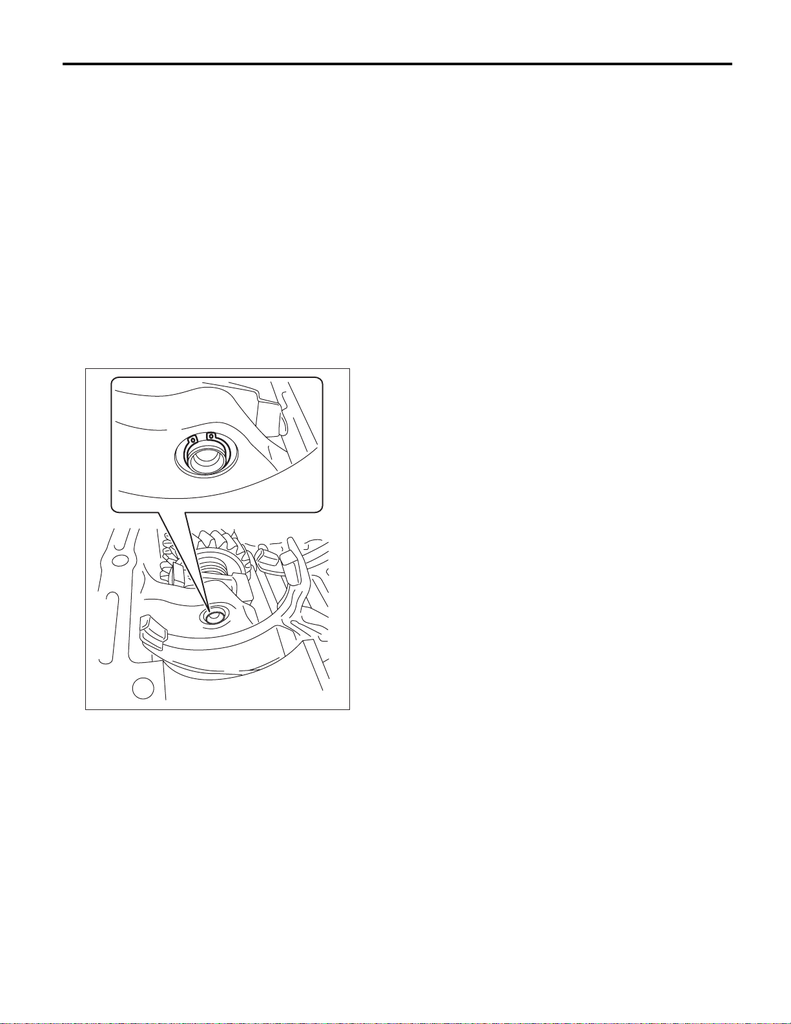

6MT(TY75)-123

Reverse Idler Gear

MANUAL TRANSMISSION AND DIFFERENTIAL

19.Reverse Idler Gear

A: REMOVAL

1) Remove the manual transmission assembly from the vehicle. <Ref. to 6MT(TY75)-25, REMOVAL, Manual

Transmission Assembly.>

2) Remove the back-up light switch and the neutral position switch. <Ref. to 6MT(TY75)-45, REMOVAL,

Switches and Harness.>

3) Remove the transfer case together with the extension case assembly. <Ref. to 6MT(TY75)-51, REMOV-

AL, Transfer Case and Extension Case Assembly.>

4) Remove the transmission case. <Ref. to 6MT(TY75)-79, REMOVAL, Transmission Case.>

5) Remove the drive pinion shaft assembly. <Ref. to 6MT(TY75)-92, REMOVAL, Drive Pinion Shaft Assem-

bly.>

6) Remove the main shaft assembly. <Ref. to 6MT(TY75)-83, REMOVAL, Main Shaft Assembly for Single-

Range.>

7) Remove the front differential assembly. <Ref. to 6MT(TY75)-111, REMOVAL, Front Differential Assem-

bly.>

8) Shift into 4th.

9) Remove the snap ring.

MT-02516

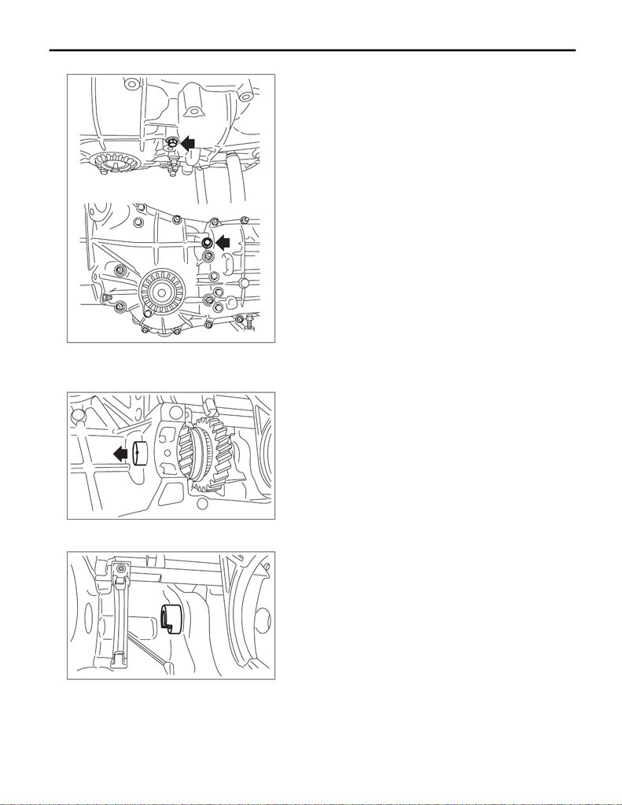

6MT(TY75)-124

Reverse Idler Gear

MANUAL TRANSMISSION AND DIFFERENTIAL

10) Remove the reverse idler gear shaft securing bolt.

11) Remove the reverse idler gear shaft by pushing it out.

NOTE:

Support the reverse idler gear assembly with hands to avoid collapsing.

12) Remove the reverse idler gear.

13) Remove the reverse idler gear bushing.

MT-02517

MT-02518

MT-02519

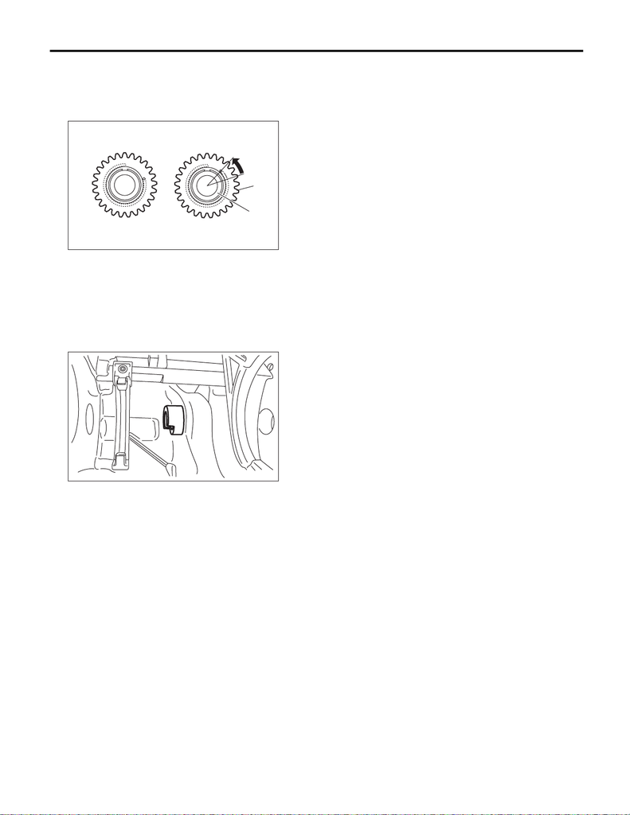

6MT(TY75)-125

Reverse Idler Gear

MANUAL TRANSMISSION AND DIFFERENTIAL

B: INSTALLATION

NOTE:

Rotate the reverse idler sub gear by two teeth from free status in the direction of the arrow to make it engage

with the reverse gear of the main shaft and install the main shaft assembly.

1) Install the reverse idler gear bushing with the cutout portion of the reverse idler gear bushing facing the

front of the transmission.

MT-02684

(C)

(A)

(B)

(D)

(A) Free status

(B) Set status

(C) Reverse idler sub gear

(D) Reverse idler gear

MT-02519

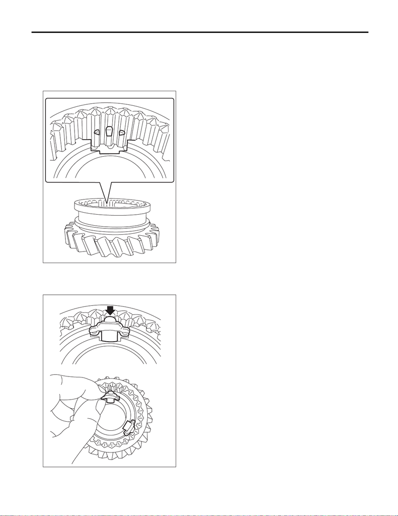

6MT(TY75)-126

Reverse Idler Gear

MANUAL TRANSMISSION AND DIFFERENTIAL

2) Assembling reverse idler gear assembly

(1) Install the reverse coupling sleeve to the reverse idler gear No. 2.

NOTE:

• Install the reverse coupling sleeve in the correct direction.

• Make sure that the oval-shaped cutout portion inside the reverse coupling sleeve matches the center of the

reverse idler gear No. 2 groove.

(2) Install the reverse shifting insert.

NOTE:

Press in the ball part to install.

MT-02520

MT-02521

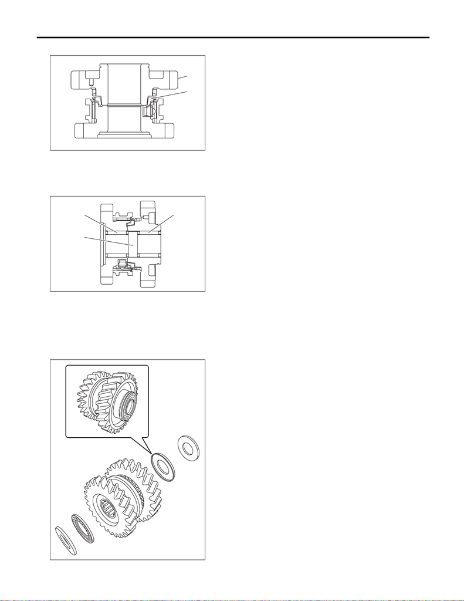

6MT(TY75)-127

Reverse Idler Gear

MANUAL TRANSMISSION AND DIFFERENTIAL

(3) Install the reverse baulk ring and reverse idler gear.

(4) Install the needle bearing and reverse idler gear collar.

(5) Install the thrust bearing and reverse idler gear washer.

NOTE:

Install the thrust bearing in the correct direction.

MT-02522

(A)

(B)

(A) Reverse idler gear

(B) Reverse baulk ring

MT-02523

(A) (A)

(B)

(A) Needle bearing

(B) Reverse idler gear collar

MT-02524

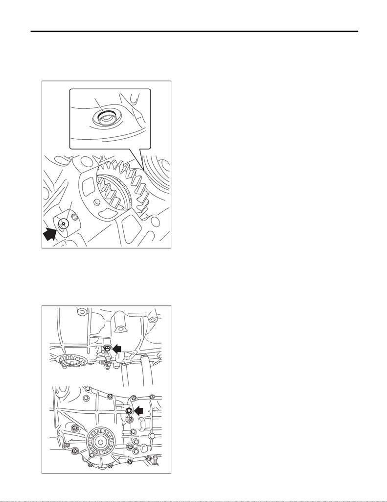

6MT(TY75)-128

Reverse Idler Gear

MANUAL TRANSMISSION AND DIFFERENTIAL

3) Install the assembled reverse idler gear assembly to the transmission case and hold it with hands.

4) Install the reverse idler gear shaft.

NOTE:

• Install with the cutout portion of the reverse idler gear shaft facing the RH side of the transmission case.

• Make sure that the groove of the reverse idler gear shaft comes out of the reverse idler gear bushing.

5) Install the reverse idler gear shaft securing bolt.

Tightening torque:

25 N·m (2.5 kgf-m, 18.4 ft-lb)

MT-02525

(A)

(B)

(A) Cutout portion of the reverse idler gear shaft

(B) Snap ring installation groove

MT-02517

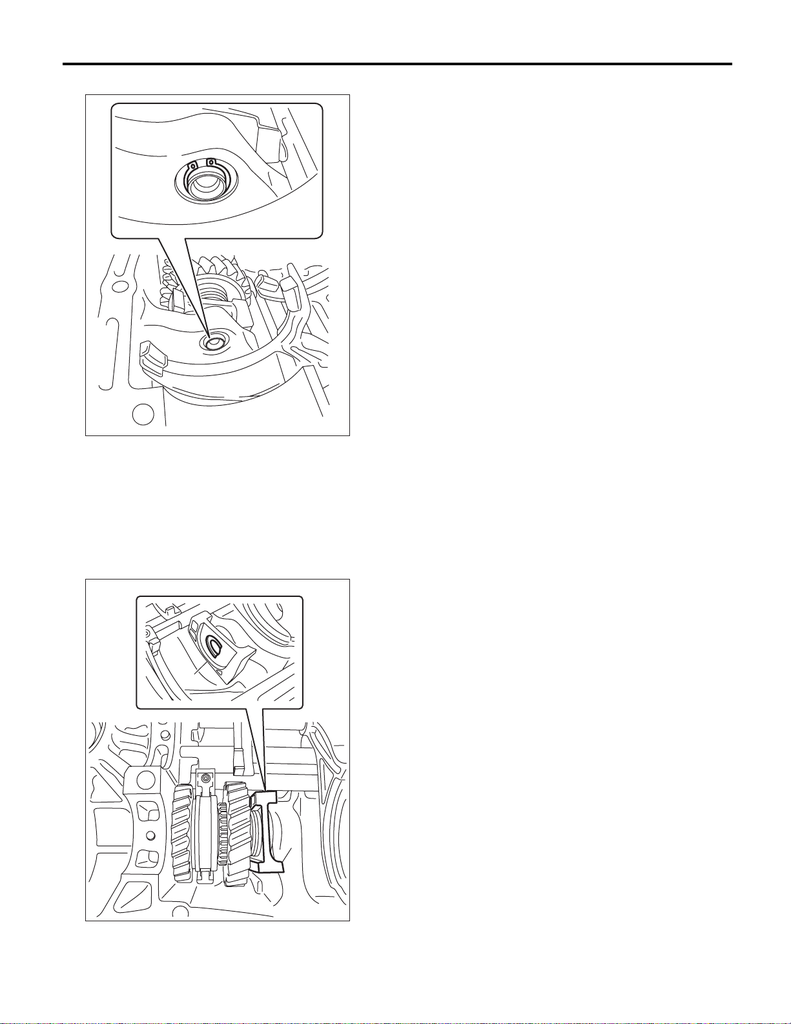

6MT(TY75)-129

Reverse Idler Gear

MANUAL TRANSMISSION AND DIFFERENTIAL

6) Install the snap ring.

7) Select the reverse idler gear bushing. <Ref. to 6MT(TY75)-134, ADJUSTMENT, Reverse Idler Gear.>

8) Remove the reverse idler gear assembly and replace with the selected bushing. <Ref. to 6MT(TY75)-123,

REMOVAL, Reverse Idler Gear.>

9) Install the reverse idler gear assembly, oil case guide and reverse idler gear shaft.

NOTE:

• Install with the cutout portion of the reverse idler gear shaft facing the RH side of the transmission case.

• Make sure that the groove of the reverse idler gear shaft comes out of the reverse idler gear bushing.

• Insert the cutout portion of the reverse idler gear bushing into the oil case guide.

MT-02516

MT-02531

(A)

(A)

(A) Oil case guide

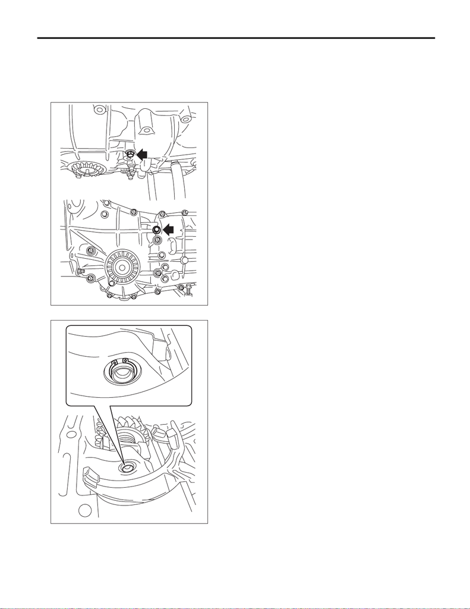

6MT(TY75)-130

Reverse Idler Gear

MANUAL TRANSMISSION AND DIFFERENTIAL

10) Install the reverse idler gear shaft securing bolt.

NOTE:

Use a new gasket.

Tightening torque:

25 N·m (2.5 kgf-m, 18.4 ft-lb)

11) Install the snap ring.

MT-02517

MT-02516

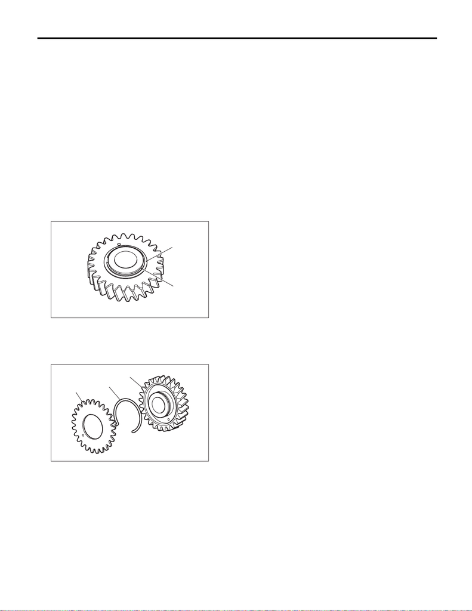

6MT(TY75)-131

Reverse Idler Gear

MANUAL TRANSMISSION AND DIFFERENTIAL

12) Check the reverse shifter fork. <Ref. to 6MT(TY75)-140, INSPECTION, Shifter Fork and Rod.>

13) Install the front differential assembly. <Ref. to 6MT(TY75)-112, INSTALLATION, Front Differential As-

sembly.>

14) Install the main shaft assembly. <Ref. to 6MT(TY75)-83, INSTALLATION, Main Shaft Assembly for Sin-

gle-Range.>

15) Install the drive pinion shaft assembly. <Ref. to 6MT(TY75)-92, INSTALLATION, Drive Pinion Shaft As-

sembly.>

16) Install the transmission case. <Ref. to 6MT(TY75)-80, INSTALLATION, Transmission Case.>

17) Install the transfer case together with the extension case assembly. <Ref. to 6MT(TY75)-53, INSTALLA-

TION, Transfer Case and Extension Case Assembly.>

18) Install the back-up light switch and the neutral position switch. <Ref. to 6MT(TY75)-46, INSTALLATION,

Switches and Harness.>

19) Install the manual transmission assembly to the vehicle. <Ref. to 6MT(TY75)-30, INSTALLATION, Man-

ual Transmission Assembly.>

C: DISASSEMBLY

1. REVERSE IDLER GEAR ASSY

1) Remove the snap ring and friction plate.

2) Remove the reverse idler sub gear and reverse idler spring.

MT-02673

(A)

(B)

(A) Friction plate

(B) Snap ring

MT-02672

(A)

(B)

(C)

(A) Reverse idler sub gear

(B) Reverse idler spring

(C) Reverse idler gear

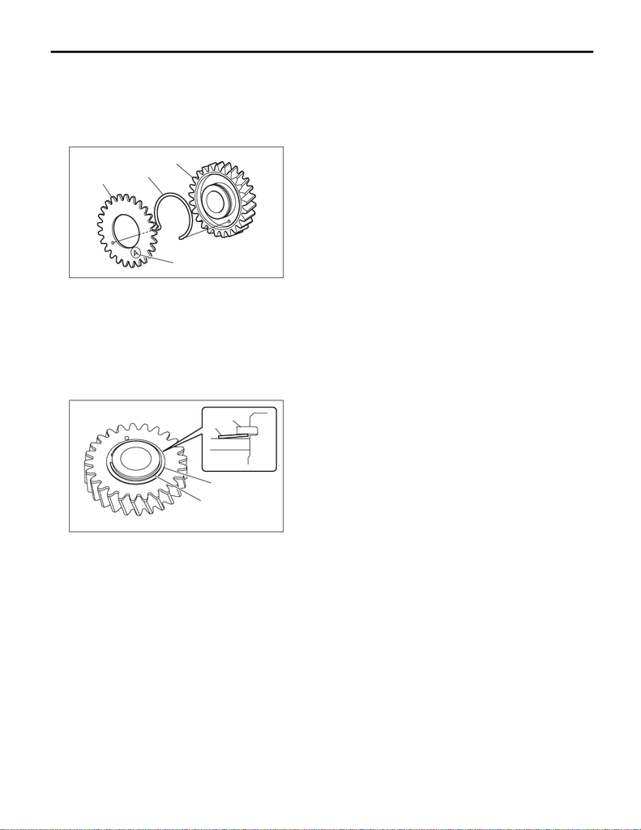

6MT(TY75)-132

Reverse Idler Gear

MANUAL TRANSMISSION AND DIFFERENTIAL

D: ASSEMBLY

1. REVERSE IDLER GEAR ASSY

1) Attach the reverse idler sub gear and reverse idler spring.

NOTE:

Point the stamp (marking A) towards the outside, and install the reverse idler sub gear.

2) Install the friction plate and snap ring.

NOTE:

Make sure the friction plate is installed in the proper direction.

MT-02675

(A)

(D)

(B)

(C)

(A) Reverse idler sub gear

(B) Reverse idler spring

(C) Reverse idler gear

(D) Stamp (marking A)

MT-02674

(A)

(B)

(B)

(A)

(A) Friction plate

(B) Snap ring

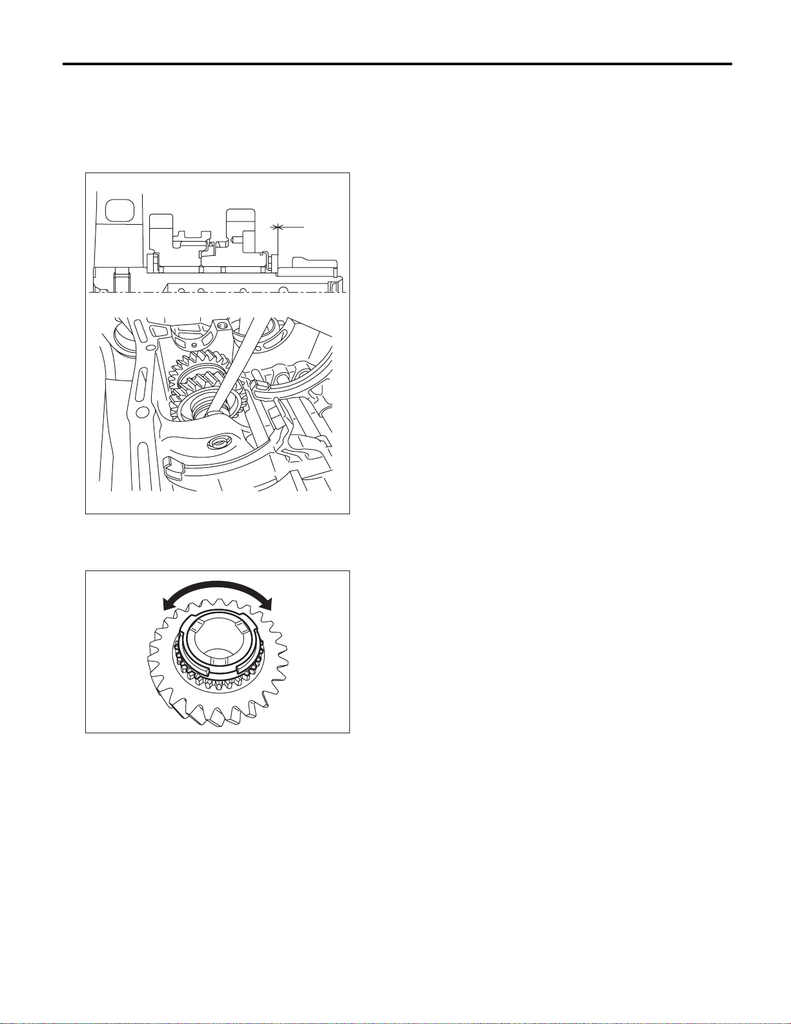

6MT(TY75)-133

Reverse Idler Gear

MANUAL TRANSMISSION AND DIFFERENTIAL

E: INSPECTION

1) Check the clearance between the reverse idler gear bushing and reverse idler gear washer. If the value

is out of specification, select the appropriate reverse idler gear bushing and adjust.

Clearance (a):

0.1 — 0.3 mm (0.004 — 0.012 in)

2) Check the reverse idler gear and reverse idler gear shaft for damage. Replace if it is damaged.

3) Apply gear oil to the cone of the reverse idler gear and while press-fitting the reverse baulk ring, check

there is no rotation in the circumferential direction.

MT-02527

(a)

MT-02530

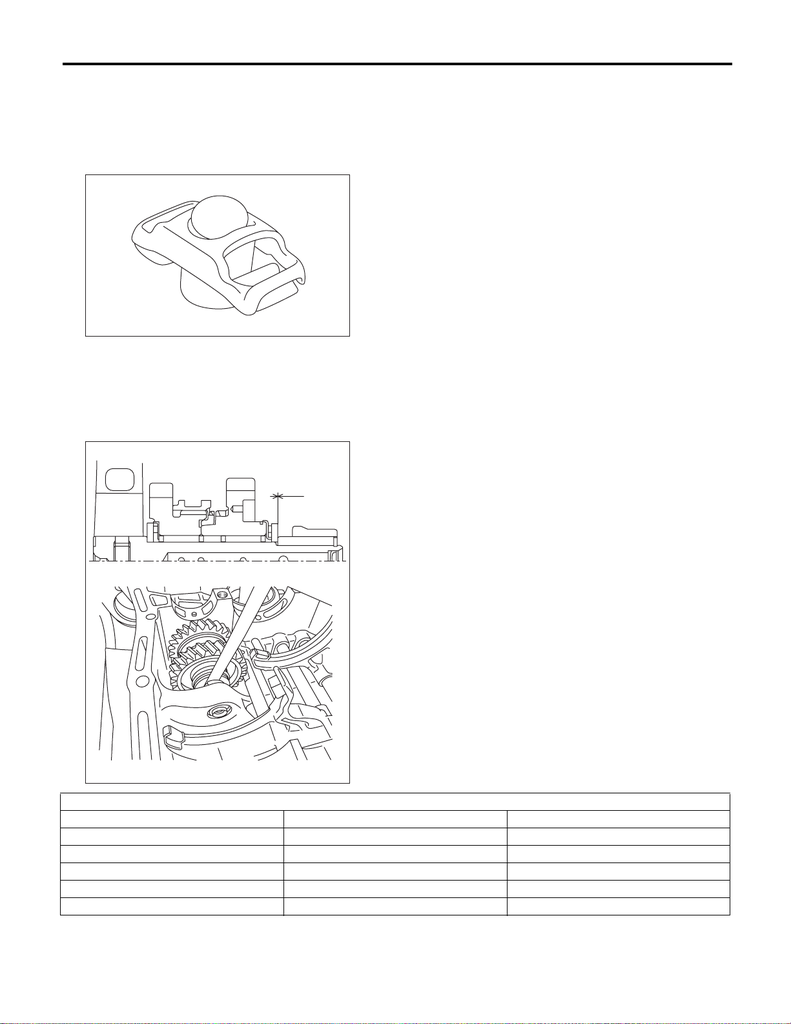

6MT(TY75)-134

Reverse Idler Gear

MANUAL TRANSMISSION AND DIFFERENTIAL

4) Reverse coupling sleeve

• Check the sliding condition of the reverse coupling sleeve.

• Check the splines on the reverse coupling sleeve and reverse idler gear for wear.

5) Reverse shifting insert

Replace the reverse shifting insert if there is deformation, excessive wear on the ball section or any defec-

tiveness.

F: ADJUSTMENT

1) Select the appropriate reverse idler gear bushing from the table below, and adjust until the clearance be-

tween the reverse idler gear and reverse idler gear washer is within specification.

Clearance (a):

0.1 — 0.3 mm (0.004 — 0.012 in)

MT-02493

MT-02527

(a)

Reverse idler gear bushing

Part No. Length mm (in) Groove for identification

32289AA080 27.75 (1.093) None

32289AA090 27.90 (1.098) 1

32289AA100 28.05 (1.104) 2

32289AA110 28.20 (1.110) 3

32289AA120 28.35 (1.116) 4